# Analisi esplorativa dati COVID19

comments: [A. Castiglioni](https://www.linkedin.com/in/andrea-castiglioni314/).  
Also available: [Coronavirus in Italy ODE model an parameter optimization — forecast with python](https://medium.com/@andrea.castiglioni/coronavirus-in-italy-ode-model-an-parameter-optimization-forecast-with-python-c1769cf7a511).

```
Last update 2020-07-21 17:00:00
```

## Last 3 days data

|  | data | totale_casi | totale_positivi | deceduti | Dimessi_o_deceduti | Days | variazione_totale_positivi | totcasi_pct_change | totpositivi_pct_change |
| --- | --- | --- | --- | --- | --- | --- | --- | --- | --- |
| 146 | 2020-07-19 17:00:00 | 244434 | 12440 | 35045 | 231994 | 146.0 | 72 | 0.000893 | 0.005821 |
| 147 | 2020-07-20 17:00:00 | 244624 | 12404 | 35058 | 232220 | 147.0 | -36 | 0.000777 | -0.002894 |
| 148 | 2020-07-21 17:00:00 | 244752 | 12248 | 35073 | 232504 | 148.0 | -156 | 0.000523 | -0.012577 |

Dai dati ufficiali circa il 6.0% dei positivi è attualmente ricoverato.  
Ci sono oggi 49 persone ricoverate in terapia intensiva.

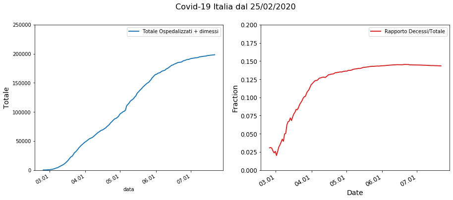

# Differenza Casi Totali nelle provincie con più casi negli ultimi giorni

L'eventuale mancanza di dati per il giorno precedente si traduce in un valore negativo.

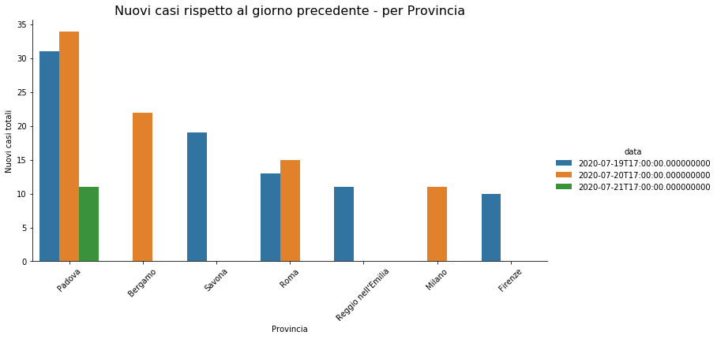

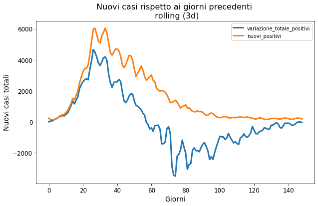

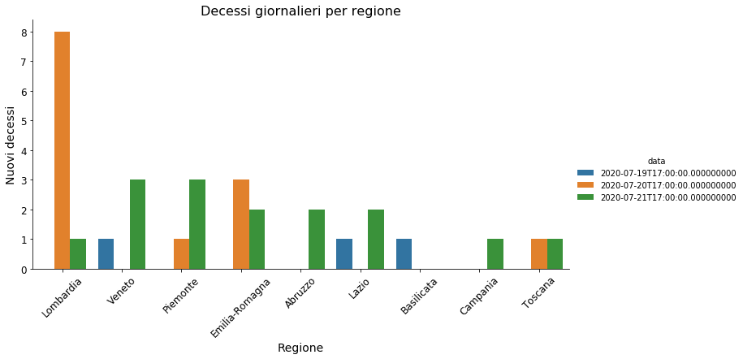

## PCA

Sezione ispirata da [Prof. Riccardo Leati](https://www.linkedin.com/posts/riccardo-leardi-2836041b_data-coronavirus-covid19-activity-6658408505638207489-9vo0/).

Il numero vicino all'indicatore rappresenta il giorno a partire dal 2020-02-24 18:00:00

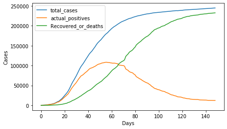

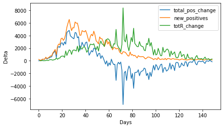

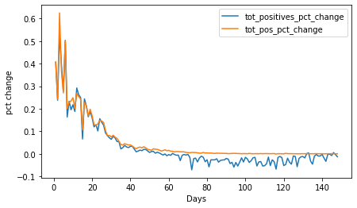

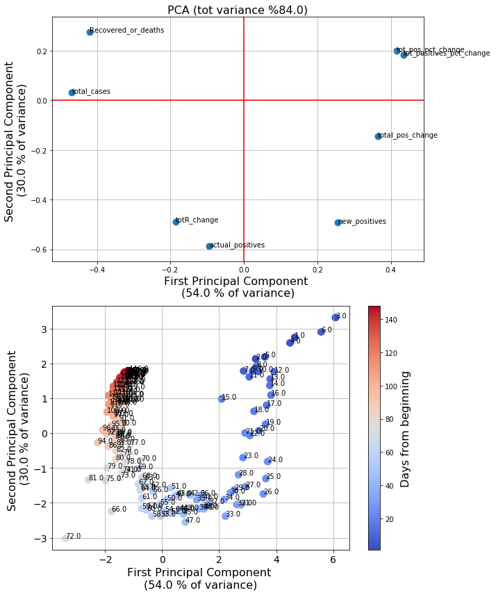

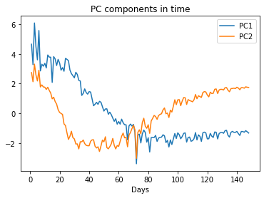

# Modello epidemiologico SIR

Il modello epidemiologico SIR individua tre categorie di persone:

- S(t) quelli che si possono ammalare
- I(t) gli infetti;
- R(t) quelli che hanno passato l'infezione e sono immuni (anche se morti).

Il modello ha due parametri:

- β che individua la frequenza di contatto effettiva tra le persone: un infetto viene a contatto con βN per unità di tempo. Di questi una frazione S/N può contrarre il virus
- γ che è la media del tempo di recupero: ossia 1/γ è il periodo medio in cui un infetto può trasmettere il virus.

$$\frac{dS}{dt} = - \beta \frac{IS}{N} $$$$\frac{dI}{dt} = \beta \frac{IS}{N} - \gamma I$$$$\frac{dR}{dt} = \gamma I$$

# 1. $\beta$ dipendente dal tempo

Con questa relazione di beta dal tempo si vuole simulare l'applicazione delle misure restrittive:

$$\beta = \beta*(1.1-c_f*t)$$

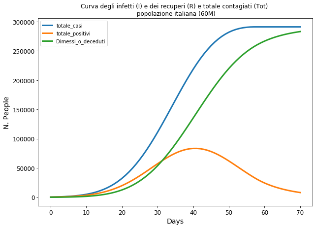

# PCA sul modello SIR

Visto la visualizzazione che ci offre la PCA, possiamo pensare di guardare con lo stesso metodo anche i dati forniti dal modello per capire come si spostano in un contesto regolato da delle regole precise.

|  | totale_casi | totale_positivi | variazione_totale_positivi | nuovi_positivi | Dimessi_o_deceduti | Days | totcasi_pct_change | totpositivi_pct_change |
| --- | --- | --- | --- | --- | --- | --- | --- | --- |
| 0 | 300.000000 | 300.000000 | NaN | NaN | 0.000000 | 0.0 | NaN | NaN |
| 1 | 432.852412 | 394.523886 | 94.523886 | 132.852412 | 38.328525 | 1.0 | 0.442841 | 0.315080 |
| 2 | 603.878232 | 515.322970 | 120.799083 | 171.025820 | 88.555263 | 2.0 | 0.395113 | 0.306190 |
| 3 | 822.487248 | 668.558245 | 153.235275 | 218.609015 | 153.929003 | 3.0 | 0.362008 | 0.297358 |
| 4 | 1099.935728 | 861.493138 | 192.934892 | 277.448480 | 238.442590 | 4.0 | 0.337329 | 0.288584 |

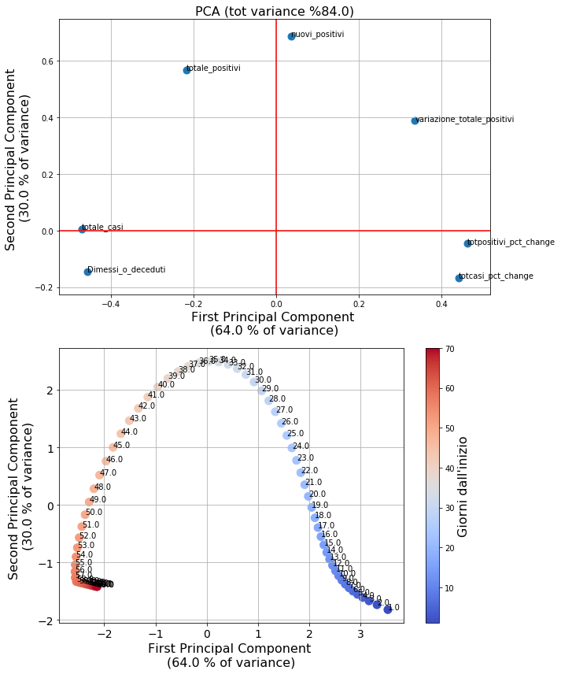

# Confronto PCA

Dal grafico sotto vediamo come il profilo delle due curve sia sostanzialmente simile. Quello che ci dobbiamo aspettare però, dal grafico della PCA, è che ora lo spostamento dei punti diventi sempre minore fino a spostarsi (fine epidemia).

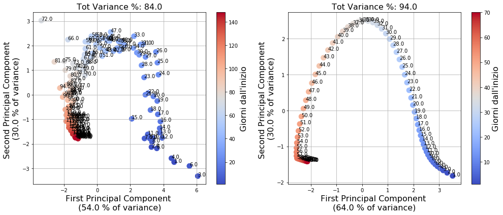

# Ottimizzazione parametri

Come ogni modello matematico, esso è una descrizione semplificata della realtà. Per avere una stima dei parametri possiamo ottimizzarli con una procedura detta ai minimi quadrati. Il valore iniziale delle variabili è:

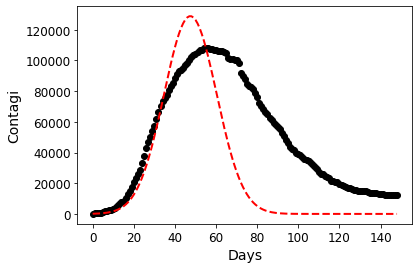

Fit Statistics

| fitting method | leastsq |  |
| --- | --- | --- |
| # function evals | 62 |  |
| # data points | 149 |  |
| # variables | 4 |  |
| chi-square | 1.7732e+11 |  |
| reduced chi-square | 1.2229e+09 |  |
| Akaike info crit. | 3121.69634 |  |
| Bayesian info crit. | 3133.71213 |  |

Variables

| name | value | initial value | min | max | vary |
| --- | --- | --- | --- | --- | --- |
| i0 | 122.005283 | 221 | 100.000000 | 600.000000 | True |
| beta_i | 0.31218966 | 0.35 | 0.10000000 | 0.50000000 | True |
| gamma | 0.05003794 | 0.11 | 0.05000000 | 0.12000000 | True |
| tau | 0.02100000 | 0.021 | 0.01500000 | 0.02500000 | True |

### Best fit con dati "Totale attualmente positivi" e "Totale Casi"

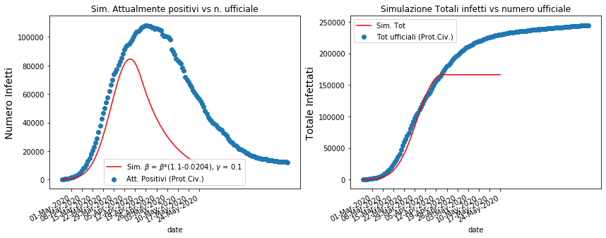

Da questi trend pare chiaro che si tiene in considerazione uno degli indicatori gli altri saranno da rivedere. In particolare la curva dei totali ufficiali risulta sottostimata. Il fit sui casi totali si ha modificando il parametro gamma da 0.1 a 0.12.  
Sia $\beta$ che $\gamma$ risentono delle misure adottate di social distancing, ma forse su una scala di tempi diversa.

## Previsione data e massimo contagiati

|  | date | Tot_low | Tot | Tot_sup |
| --- | --- | --- | --- | --- |
| 89 | 2020-05-23 18:00:00 | 166177.0 | 166177.0 | 166177.0 |

## Previsione data e massimo di casi attivi

|  | date | Istd | Tot | Days |
| --- | --- | --- | --- | --- |
| 45 | 2020-04-09 18:00:00 | 84614.0 | 151810.0 | 45.0 |

# Letalità reale, Ospedalizzati e Terapia Intensiva

Proviamo a stimare il totale infetti supponendo che i decessi siano l'1.5%, gli ospedalizzati il 20% e chi entra in terapia intensiva il 5%.

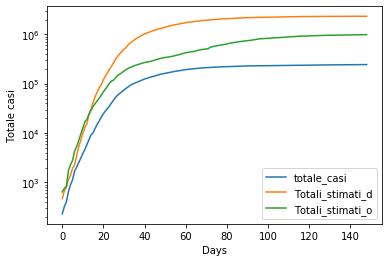

- d: deceduti
- o: ospedalizzati

|  | data | Days | DR | deceduti | totale_ospedalizzati | totale_casi | Totali_stimati_d | Totali_stimati_o |
| --- | --- | --- | --- | --- | --- | --- | --- | --- |
| 147 | 2020-07-20 17:00:00 | 147.0 | 0.143314 | 35058 | 792 | 244624 | 2337200.0 | 989770.0 |
| 148 | 2020-07-21 17:00:00 | 148.0 | 0.143300 | 35073 | 781 | 244752 | 2338200.0 | 991060.0 |

# Imperial College

Usiamo come stima dei valori totali quella ottenuta considerando la letalità l'1.5%. Usiamo lo stesso modello visto in precedenza otteniamo la nuova evoluzione dell'infezione.

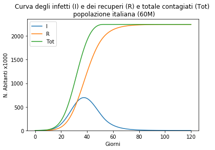

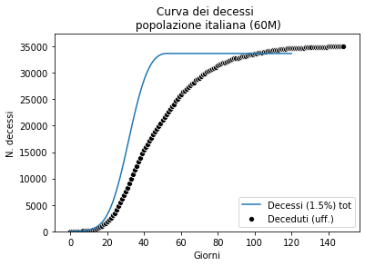

## Confronto curva dati ufficiali contro casi plausibili

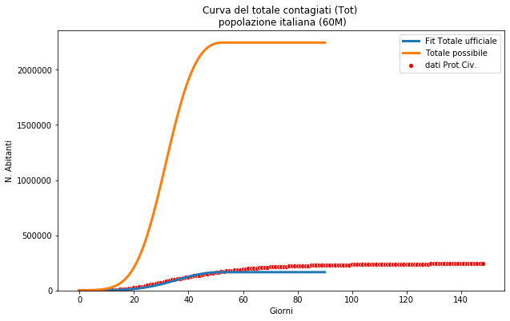

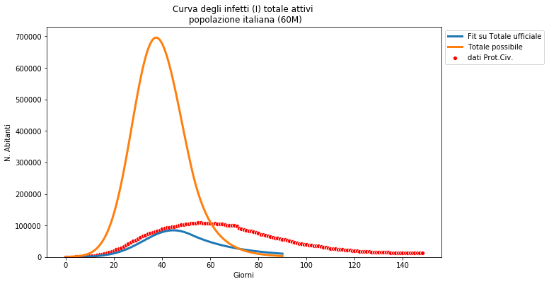

# Regioni

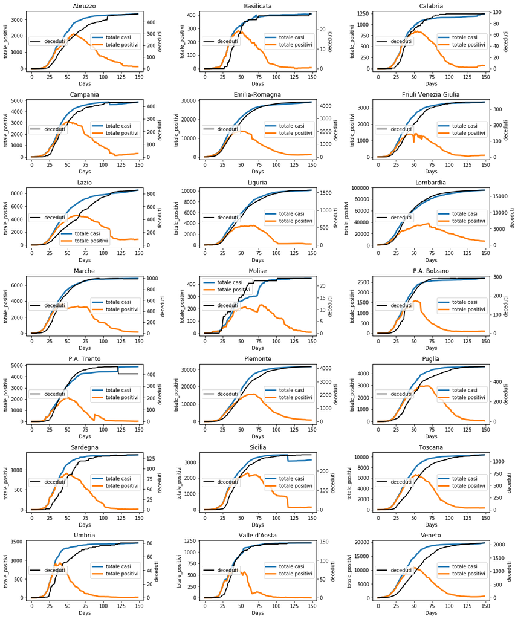